# An Exploratory Project Using GloVe Word Embeddings

Zayaan Syed

5/3/2022

## R Markdown

**Overview** In this project supervised by Dr. Michael Luvalle, I used the text2vec implementation of the GloVe Algorithm to understand how certain word relationships change over time. I will use this approach on two of Shakespeare’s Plays (*The Tragedy of King Lear* and *The Tragedy of Romeo and Juliet*) to examine how words relating to events in each play changes with respect to the main characters. We are interested in main character pairs because their relationships influence how the plot progresses. Intuitively, I suspect that some character pairs carry a larger amount of influence (e.g., Romeo+Juliet) I will do this by seeing how the vector sum of two characters changes in cosine similarity with some target word per each act in each respective play. Then, I can create a time series to visualize that change.

**GloVe Algorithm** It is an unsupervised learning algorithm for creating vector representation for words. It takes data from co-occurrence statistics amongst words from a corpus and outputs linear structures of the vector space. Here is an example of a TCM (term co-occurence matrix) GloVe would utilize:

```
                    the cat sat on mat
                the  0   1   0   1  1

                cat  1   0   1   0  0

                sat  0   1   0   1  0

                on   1   0   1   0  0

                mat  1   0   0   0  0
```

**Implementation** First thing we are going to need to do is load in our text files so we can convert it to a corpus.

Each act of *The Tragedy of King Lear*:

```r
#load packages
library(tidyverse)
library(textreadr)
library(tidytext)
```

```r
library(tidyr)
library("httr")
library(ggplot2)
library(tm)
library(text2vec)
library(widyr)
kinglear_act1 <- read.delim("C:/Users/Zayaan Syed/OneDrive/Documents/KingLearAct1.txt")
kinglear_act2 <- read.delim("C:/Users/Zayaan Syed/OneDrive/Documents/kinglearact2.txt")
kinglear_act3 <- read.delim("C:/Users/Zayaan Syed/OneDrive/Documents/kinglearact3.txt")
kinglear_act4 <- read.delim("C:/Users/Zayaan Syed/OneDrive/Documents/kinglearact4.txt")
finalactkinglear <- read.delim("C:/Users/Zayaan Syed/OneDrive/Documents/finalactkinglear.txt")
```

.. and *The Tragedy of Romeo and Juliet*

```r
randj_act1 <- read.delim("C:/Users/Zayaan Syed/OneDrive/Documents/RandJAct1.txt")
randj_act2 <- read.delim("C:/Users/Zayaan Syed/OneDrive/Documents/randjact2.txt")
randj_act3 <- read.delim("C:/Users/Zayaan Syed/OneDrive/Documents/randjact3.txt")
randj_act4 <- read.delim("C:/Users/Zayaan Syed/OneDrive/Documents/act4randj.txt")
finalactrandj <- read.delim("C:/Users/Zayaan Syed/OneDrive/Documents/romeoandjulietfinalact.txt")
```

Notice how I load in each act separately. I do this because I want to see how word relationships change from act to act.

Additionally, unlike *The Tragedy of Romeo and Juliet*, I have not actually read *The Tragedy of King Lear*. So, I have some idea of how words will change in Romeo and Juliet but not in King Lear. Part of this experiment will be to see if after reading King Lear, do the word embeddings that change align with the plot.

Below, I will outline the general steps I did to get the cosine similarity for each act’s word embeddings. For simplicity I will use one act throughout this whole outline.

```r
# open a connection to file
con <- file("C:/Users/Zayaan Syed/OneDrive/Documents/romeoandjulietfinalact.txt",open="r")
# read file contents
data1 <- readLines(con)
# close the connection
close(con)
```

I intentionally use the final act first in this experiment, because I want to track how word embeddings change moving backwards. We get a better sense of what words, events, and character relationships are most interesting to look at based on the last act because it is when the resolution of the play occurs. Most major plot issues are addressed here (or so I suspect).

We need to create vocabulary for which we want to learn word vectors. We do this in the following way:

```r
# Create iterator over tokens
tokens = space_tokenizer(data1)
# Create vocabulary. Terms will be unigrams (simple words).
it = itoken(tokens, progressbar = FALSE)
vocab = create_vocabulary(it)
```

We do not want words that are so uncommon. More specifically we cannot calculate a word vector which only appeared once in the text. So we will only take words which appear at least five times. We can do that using text2vec’s prune_vocabulary() function.

```r
vocab = prune_vocabulary(vocab, term_count_min = 5L)
```

Now we are ready to contruct the term-co-occurence matrix (TCM).

```r
# Use our filtered vocabulary
vectorizer = vocab_vectorizer(vocab)
# use window of 5 for context words
tcm = create_tcm(it, vectorizer, skip_grams_window = 5L)
```

Now since we have the TCM matrix we can implement the GloVe algorithm. text2vec uses a parallel stochastic gradient descent algorithm.

Now to fitting the model.

```r
glove = GlobalVectors$new(rank = 50, x_max = 10)
wv_main = glove$fit_transform(tcm, n_iter = 10, convergence_tol = 0.01, n_threads = 8)
```

```
## INFO  [16:20:38.837] epoch 1, loss 0.1811
## INFO  [16:20:38.889] epoch 2, loss 0.0831
## INFO  [16:20:38.905] epoch 3, loss 0.0589
## INFO  [16:20:38.909] epoch 4, loss 0.0451
## INFO  [16:20:38.913] epoch 5, loss 0.0359
## INFO  [16:20:38.921] epoch 6, loss 0.0293
## INFO  [16:20:38.925] epoch 7, loss 0.0243
## INFO  [16:20:38.925] epoch 8, loss 0.0204
## INFO  [16:20:38.929] epoch 9, loss 0.0173
## INFO  [16:20:38.933] epoch 10, loss 0.0148
```

```r
dim(wv_main)
```

```
## [1] 119  50
```

The model learns two sets of word vectors - main and context. Essentially they are the same since the model is symmetric. From experience, learning two sets of word vectors leads to higher quality embeddings.

```r
wv_context = glove$components
dim(wv_context)
```

```
## [1]  50 119
```

The GloVe paper teaches us that it is usually better to average or take the sum of the main and context vector:

```r
word_vectors = wv_main + t(wv_context)
```

```r
Romeo = word_vectors["Friar", , drop = FALSE]
cos_sim = sim2(x = word_vectors, y = Romeo, method = "cosine", norm = "l2")
head(sort(cos_sim[,1], decreasing = TRUE), 50)
```

```
##      Friar      would        not         We      Enter      these        how
## 1.00000000 0.39478765 0.36529065 0.34962815 0.34849731 0.32069300 0.30684194
##        for        yet       doth       That        but       same         an
## 0.30684125 0.28564136 0.25238477 0.24997226 0.23450854 0.21629165 0.21616045
##         if        man    Juliet.      John.        But       dead       give
## 0.15605986 0.15398705 0.15370582 0.14219790 0.14155779 0.13112211 0.12504938
##        How        our       This       then       must       thou         of
## 0.12340201 0.12216306 0.11658211 0.11627626 0.09748004 0.09692399 0.09391344
##        are        did       come    Romeo's       Rom.    Prince.         am
## 0.08797779 0.08480309 0.08042818 0.07604329 0.07410641 0.07179860 0.06716321
##        can       Par.         no       some      shall       upon        bid
## 0.06261917 0.05731091 0.05560060 0.05415715 0.05316335 0.04984131 0.04574701
##       what       have          O       your     Juliet       Bal.         on
## 0.04516943 0.04140811 0.04052523 0.03710066 0.03353238 0.03099492 0.02697911
##         up
## 0.02661867
```

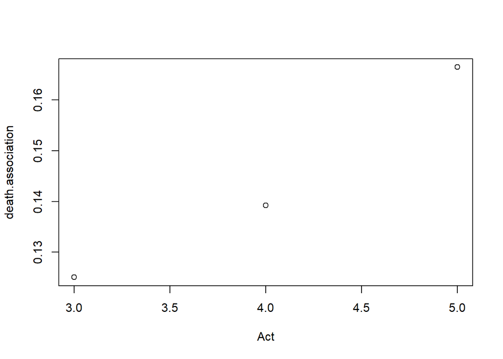

```r
Act <- c(3,4,5)
death.association <- c(.12508,.13923,.16648)
plot(Act,death.association)
```

I went ahead and applied the same method above to *The Tragedy of King Lear*. The only character name pair that I could use in the model is “Cordelia+Lear.” Again, for some reason I could not create a sum out of any other name pair (perhaps due to some restriction within within our corpus). I find that the only words that consistently appears within most Acts with respect to the vector sum is “father.” I find this a bit redundant since the word pair is father+daughter in the play. So the cosine similarity between this word pair and “father” is nonexistent is Act 5, .14949 in Act 4, .02297 in Act 3, .31483 in Act 2, and .04600 in Act 1.

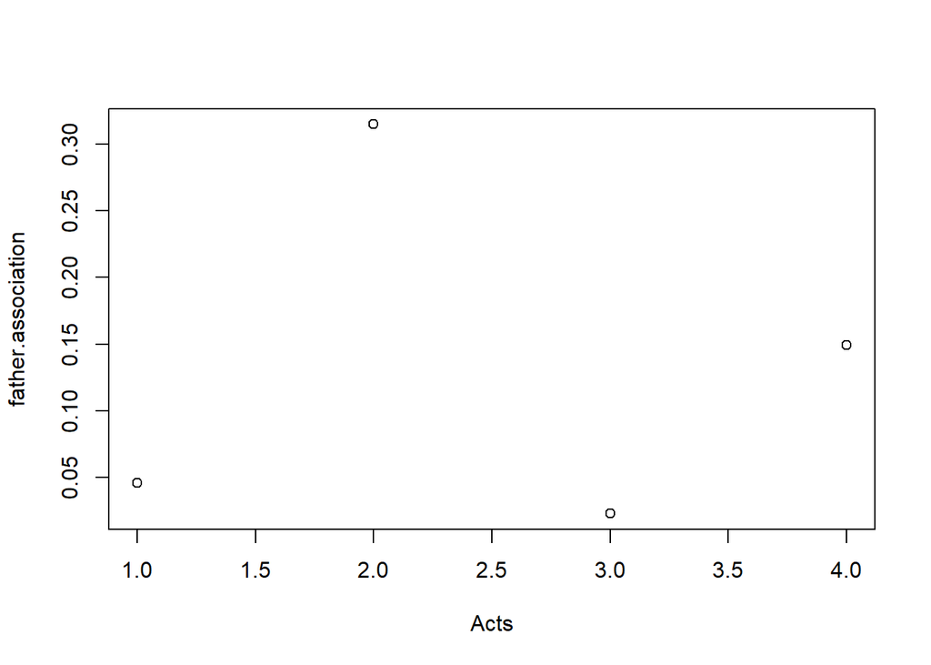

```r
Acts <- c(1,2,3,4)
father.association <- c(.04600,.31483,.02297, .14949)
plot(Acts,father.association)
```

According to this graph, the word association as the acts progress is inconsistent. This makes sense when considering the play itself. King Lear disowns his daughter Cordelia at the very beginning of the play which sets most of the plot in motion. He then switches between regretting that decision on and off throughout the play, so his sentiment towards Cordelia changes. Hence, it makes sense that the word association is unpredictable.

**Conclusion**

The biggest issue in this experiment is that I did not have the ability to explore multiple word associations throughout each act. This is because the corpi was very limiting. We would probably need more in the corpus to build up the semantics of the system. Additionally, I suspect the the GloVe algorithm limits what we can vectorize.

If I were to do this experiment again I would use less restrictive vocabulary. One idea is using a very large historical newspaper (think one million or more) collection so I can track more meaningful word associations over a large time period.